# Question

*S-ID.A: Summarize, represent, and interpret data on a single count or measurement variable. Use calculators, spreadsheets, and other technology as appropriate.*

A sample of size $n=200$ was taken from an unknown population. The sample is shown below:

3.35, 4.25, 1.98, 1.94, 2.98, 8.99, 7.55, 9.49, 3.83, 5.50, 1.93, 9.72, 6.03, 0.20, 2.91, 6.89, 0.30, 0.14, 2.12, 8.08, 0.00, 4.31, 6.03, 8.47, 1.37, 7.95, 8.91, 1.51, 3.49, 8.89, 8.35, 6.87, 7.50, 0.95, 2.22, 4.15, 5.60, 1.35, 7.40, 5.51, 5.74, 9.56, 0.74, 1.93, 9.69, 1.86, 9.74, 2.13, 9.71, 1.24, 5.90, 7.79, 2.52, 6.33, 3.80, 6.46, 1.44, 2.81, 4.73, 4.36, 1.21, 5.63, 0.15, 0.03, 9.76, 4.82, 5.06, 3.14, 5.09, 2.95, 6.22, 0.55, 7.78, 5.66, 1.51, 9.69, 9.80, 7.61, 2.31, 0.87, 8.41, 2.25, 6.61, 8.35, 5.89, 9.81, 5.12, 8.63, 4.84, 7.21, 6.57, 5.22, 9.61, 0.09, 6.71, 3.72, 6.21, 7.94, 2.84, 7.41, 1.67, 2.85, 5.93, 1.88, 3.92, 8.32, 6.01, 8.97, 5.87, 1.47, 9.79, 8.57, 8.62, 9.78, 1.60, 9.61, 5.09, 1.84, 5.35, 6.05, 0.18, 8.20, 9.66, 1.26, 2.12, 3.28, 2.65, 2.14, 6.29, 3.27, 5.62, 0.04, 2.36, 9.26, 8.18, 3.23, 3.51, 7.68, 4.16, 5.10, 0.82, 7.68, 5.60, 5.92, 0.73, 2.18, 3.31, 1.87, 5.01, 7.35, 2.60, 9.87, 2.24, 3.35, 8.76, 0.24, 6.84, 7.07, 4.05, 6.08, 9.35, 7.76, 3.54, 3.07, 5.89, 7.06, 6.31, 8.49, 1.05, 1.70, 8.43, 6.69, 1.33, 6.26, 9.12, 5.36, 7.59, 1.79, 2.75, 3.54, 5.21, 5.74, 8.67, 0.31, 5.79, 4.70, 1.16, 9.73, 1.24, 6.59, 1.92, 5.41, 5.95, 7.63, 8.45, 2.66, 4.17, 8.26, 9.08, 0.76

Use those data to draw a histogram.

**Identify the correct histogram below and describe the shape.** Note, the bucket size is 1.

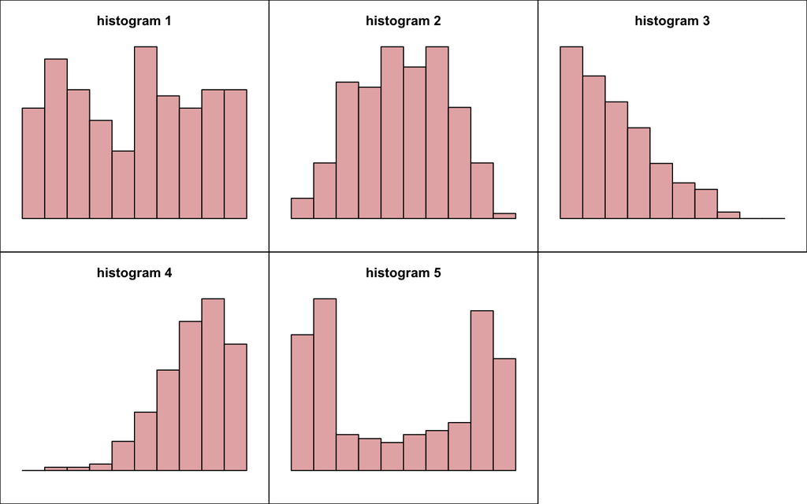

- Which histogram is appropriate? ##ANSWER1##
- Which shape description is appropriate? ##ANSWER2##

## Answerlist

- histogram 1
- histogram 2
- histogram 3
- histogram 4
- histogram 5
- Bell
- Uniform
- Bimodal
- Positive-skew
- Negative-skew

# Solution

You should make a histogram using a spreadsheet. Copy data into spreadsheet. Highlight data. Click `Insert`. Click `Chart`. Choose Histogram.

- Under `Customize`, select `Histogram`. Set bucket size to 1.
- Under `Customize`, select `Horizontal axis`. Set min to 0.

The correct histogram is number 1.

The correct description is Uniform.

- **References**
  - Skewness.
  - [Bimodal](https://en.wikipedia.org/wiki/Multimodal_distribution)
  - [Uniform](https://en.wikipedia.org/wiki/Continuous_uniform_distribution)
  - [Bell shaped](https://en.wikipedia.org/wiki/Bell-shaped_function)

# Meta-information

extype: cloze exclozetype: schoice|schoice exsolution: 10000|01000 exname: identify_histogram extol: 0 exextra[numwidth]: 999.999